# Command Line Interface, Git and GitHub

Stephanie Canovas

January 2016

## Command Line Interface

### CLI overview

**What is the Command Line Interface?**

- Old **text-based interface** for interacting with applications and operating systems.
- GUI (Graphical User Interface) used in the latest operating systems.
- **Windows:** Git Bash, **MAC OS/Linux:** Terminal.
- **What can the CLI do?**
  - *Navigate* folders (= directories)
  - *Create* and *edit* files, folders and programs
  - *Run* computer programs
- **Basics of directories**
  - Directories are organized like a tree.
  - Root directory (top of the tree): `/`
  - Home directory: `~`
  - *Path*: set of directories up to the root directory

### CLI commands

- Recipe: **command**, **flags**, **arguments**
  - *command*: does specific task
  - *flags*: options to trigger certains behaviors (preceded by `-`). They can be combined
  - *arguments*: what will be modified or other options
  - There can be zero or more flags and arguments
- `pwd`: print working directory
- `clear`: clear out commands in window
- `ls`: lists files and folders
  - `-a`: see all (hidden and unhidden)
  - `-al`: details for all
- `cd`: takes to home directory
  - `<path>`: change directory
  - `..`: change directory one level up
- `mkdir <new directory name>`: make (create) directory
- `touch <new file name>`: create an empty file
- `cp`: copy
  - `cp <file> <path>`: copy file to a directory
  - `cp -r <copied directory> <directory>`: copy the contents of a directory to another one
- `vi <file>`: make changes to a file directly in the console
- `rm <file>`: remove a file
  - `rm -r`: delete entires directories and their contents (no undo!)
- `mv <file> <directory>`: move file from cwd to directory
  - `mv <file> <new file name>`: rename file
- `echo <argument>`: print argument
- `date`: print today’s date
- Handling directories’ names containing spaces: use`\`

## Version control

### Version control overview

- **What is Version control (VC) ?**
  - System that records changes to a file or set of files over time. You can recall specific version later.
- **Different Version Control Systems**
  - **Local** (issue: keep file versions and avoid mistakes):
    - Simple database on the local computer that keeps all changes to files under revision control
    - *RCS* (most popular) keeps patch sets (differences between files) to recreate files at any version

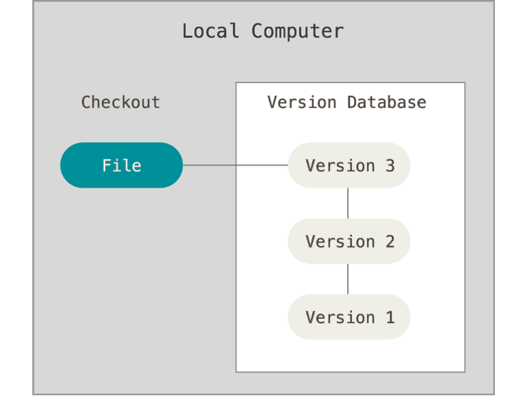

- **Centralized** (issue: collaboration with other systems):
  - Single server that contains all the versioned files
  - *Advantages*: everyone knows what everyone else is doing and administrators have control
  - *Downsides*: losing all in case of failure of the centralized server

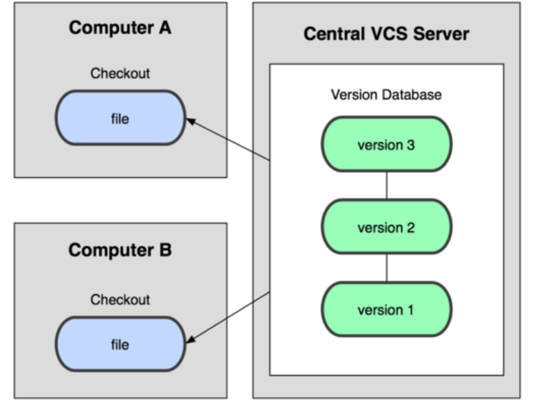

- **Distributed (DVCS)** (issue: efficiency and back up. **Git**)
  - Every collaborator’s checkout is a full backup/copy of all the data (locally)
  - Collaborators can work on the same documents at the same time
  - They can work offline

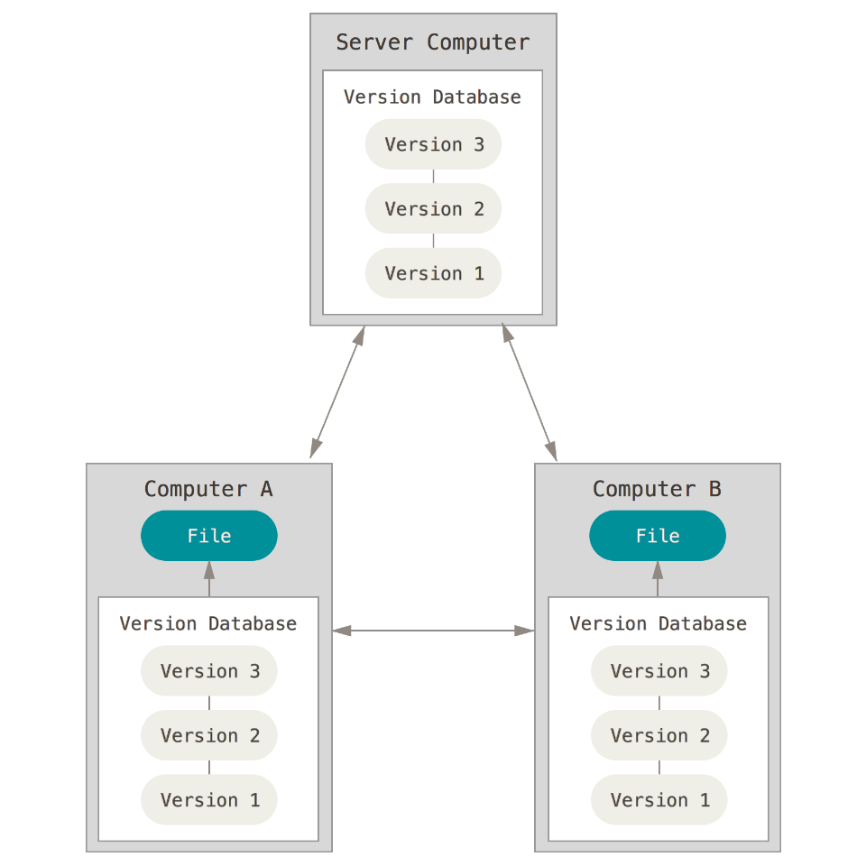

## Git

### Git overview

- **What is Git?**
  - Free open source distributed version control system that handles small and large projects with speed and efficiency
  - Created by Linux’s team. Most popular VC.
  - Everything stored in local repositories on the computer
  - Operated from command line
  - `$`: type a command
- **Git structure**
  - **workspace**: directory you are currently working in on the files
  - **index** (or **staging area**): files that should be controlled under VC
  - **local repository**: files that are stored under VC on your local computer
  - **remote repository**: hosted on GitHub (or other)
- **Git workflow**
  - Make changes to files in workspace (Git works with changes, not files)
  - **Add** files to the staging area: update index
  - **Commit** changes from workspace to local repository
  - **Push** commits to remote repository
- **How to share?**
  - push local repository to a remote repository
  - people can pull that repository down, make changes and push back up their changes
  - Access control configuration: taken care by remote repository hosting solution (Git doesn’t care about access control)
  - Hosted solutions: GitHub or GitBucket
  - Self-managed: Gitosis or Gitorious

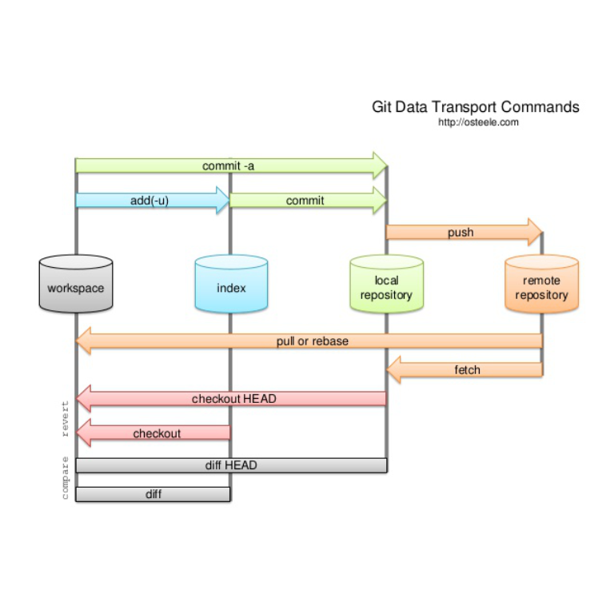